# Project_Machine Learning_Personal Loan Campaign

## FEATURE ENGINEERING & DATA PREPARATION FOR MODELLING

```python
from sklearn.model_selection import train_test_split
from sklearn.preprocessing import StandardScaler
```

```python
# Dropping duplicate row if any.

df = df.drop_duplicates()
```

```python
# Dropping columns not useful for modeling.
# ID and ZIPcode are identifiers — no predictive power

df.drop(['ID', 'ZIPCode'], axis=1, inplace=True)
```

```python
df.head()
```

|  | Age | Experience | Income | Family | CCAvg | Education | Mortgage | Personal_Loan | Securities_Account | CD_Account | Online | CreditCard |
| --- | --- | --- | --- | --- | --- | --- | --- | --- | --- | --- | --- | --- |
| 0 | 25 | 1 | 49 | 4 | 1.6 | 1 | 0 | 0 | 1 | 0 | 0 | 0 |
| 1 | 45 | 19 | 34 | 3 | 1.5 | 1 | 0 | 0 | 1 | 0 | 0 | 0 |
| 2 | 39 | 15 | 11 | 1 | 1.0 | 1 | 0 | 0 | 0 | 0 | 0 | 0 |
| 3 | 35 | 9 | 100 | 1 | 2.7 | 2 | 0 | 0 | 0 | 0 | 0 | 0 |
| 4 | 35 | 8 | 45 | 4 | 1.0 | 2 | 0 | 0 | 0 | 0 | 0 | 1 |

```python
# Feature Scaling

scaler = StandardScaler()
```

```python
# Scaling only numerical continuous variables

scale_cols = ['Age','Experience','Income','CCAvg','Mortgage']
df[scale_cols] = scaler.fit_transform(df[scale_cols])
```

```python
# Assigning the Variable to X and y

X = df.drop('Personal_Loan', axis=1)
y = df['Personal_Loan']
```

```python
# VIF (Variance Inflation Factor) Calculation

from statsmodels.stats.outliers_influence import variance_inflation_factor
import statsmodels.api as sm

X = sm.add_constant(X)
vif_data = pd.DataFrame()
vif_data["Variable"] = X.columns
vif_data["VIF"] = [variance_inflation_factor(X.values, i) for i in range(X.shape[1])]

vif_data
```

|  | Variable | VIF |
| --- | --- | --- |
| 0 | const | 12.632750 |
| 1 | Age | 22.464798 |
| 2 | Experience | 22.422247 |
| 3 | Income | 1.854995 |
| 4 | Family | 1.032347 |
| 5 | CCAvg | 1.724028 |
| 6 | Education | 1.054983 |
| 7 | Mortgage | 1.051343 |
| 8 | Securities_Account | 1.136832 |
| 9 | CD_Account | 1.328958 |
| 10 | Online | 1.039525 |
| 11 | CreditCard | 1.107961 |

### Observation:

Age (VIF = 22.46) and Experience (VIF = 22.42) have very high VIF values, both well above the acceptable threshold of 10.

One of these variables (usually Experience) should be dropped from the model to reduce redundancy and improve model stability.

## Model Building

```python
df.drop("Experience", axis=1, inplace = True)
X = df.drop('Personal_Loan', axis=1)
y = df['Personal_Loan']
```

```python
# Target varible, Only 9.6% accepted personal loans → data is imbalanced. Using SMOTE (Synthetic Minority Oversampling Technique) for imbalance treatment.

from sklearn.model_selection import train_test_split

X_train, X_test, y_train, y_test = train_test_split(X, y, test_size=0.3, random_state=42, stratify=y)

# Apply SMOTE on training data only
#smote = SMOTE(random_state=42)
#X_train_res, y_train_res = smote.fit_resample(X_train, y_train)

# Check new balance
#print("Before SMOTE:", y_train.value_counts())
#print("\nAfter SMOTE:", y_train_res.value_counts())
```

```python
model_names = []
accuracy_scores = []
precision_scores = []
recall_scores = []
f1_scores = []
```

```python
# Writing the user define function for model prediction and confusion matrix score.

def train_and_evaluate_model(model):
    model.fit(X_train,y_train)
    y_pred = model.predict(X_test)
    print(classification_report(y_test,y_pred))
    acc = accuracy_score(y_test,y_pred)
    y_pred_train = model.predict(X_train)
    y_pred_test = model.predict(X_test)
    train_acc = accuracy_score(y_train, y_pred_train)
    test_acc = accuracy_score(y_test, y_pred_test)
    print("Train Accuracy:", train_acc)
    print("Test Accuracy:", test_acc)
    precision = precision_score(y_test,y_pred,average='micro')
    recall = recall_score(y_test,y_pred,average='micro')
    f1 = f1_score(y_test,y_pred,average='micro')
    ConfusionMatrixDisplay.from_predictions(y_test,y_pred)
    plt.show();
    model_names.append(model)
    accuracy_scores.append(acc)
    precision_scores.append(precision)
    recall_scores.append(recall)
    f1_scores.append(f1)
```

```python
#Importing necessary library for model prediction and confusion matrix score.

from sklearn.metrics import ConfusionMatrixDisplay, classification_report, precision_score, recall_score, accuracy_score, f1_score
from sklearn.linear_model import LogisticRegression
from sklearn.neighbors import KNeighborsClassifier
from sklearn.tree import DecisionTreeClassifier
from xgboost import XGBClassifier
from sklearn.ensemble import RandomForestClassifier, ExtraTreesClassifier, AdaBoostClassifier, GradientBoostingClassifier, VotingClassifier, HistGradientBoostingClassifier, BaggingClassifier
from sklearn.svm import SVC
```

```
              precision    recall  f1-score   support

           0       0.99      0.98      0.99      1356
           1       0.85      0.92      0.88       144

    accuracy                           0.98      1500
   macro avg       0.92      0.95      0.93      1500
weighted avg       0.98      0.98      0.98      1500

Train Accuracy: 1.0
Test Accuracy: 0.9766666666666667
```

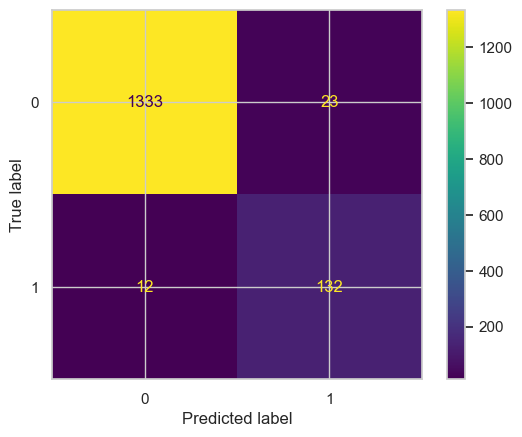

```python
train_and_evaluate_model(DecisionTreeClassifier())
```

### Observations:

**1. Model Performance Overview**

The model achieves an excellent overall performance, with:

Train Accuracy: 1.0 (100%)

Test Accuracy: 0.9767 (≈97.7%)

This indicates that the model generalizes well to unseen data, with only a slight drop from perfect training accuracy to test accuracy, suggesting minimal overfitting.

**2. Class-wise Performance**

Class 0 (Non-loan customers):

Precision: 0.99

Recall: 0.98

F1-Score: 0.99

The model identifies non-loan customers almost perfectly, with very few false positives (only 23 misclassified as loan takers).

Class 1 (Loan customers):

Precision: 0.85

Recall: 0.92

F1-Score: 0.88

The model performs slightly less accurately for loan customers but still maintains a strong balance between precision and recall.

Only 12 loan customers were misclassified as non-loan customers, showing good sensitivity.

**3. Overall Metrics**

Macro Avg F1-Score: 0.93

Weighted Avg F1-Score: 0.98

The weighted average being high confirms that the model performs consistently across both classes, despite the imbalance in the dataset (class 0 being dominant).

### Pre-Pruning — Limit Tree Growth

```
              precision    recall  f1-score   support

           0       0.99      0.99      0.99      1356
           1       0.93      0.88      0.90       144

    accuracy                           0.98      1500
   macro avg       0.96      0.93      0.95      1500
weighted avg       0.98      0.98      0.98      1500

Train Accuracy: 0.9814285714285714
Test Accuracy: 0.982
```

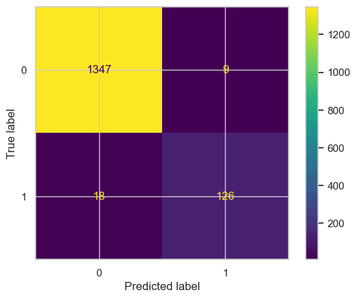

```python
train_and_evaluate_model(DecisionTreeClassifier(criterion='gini',
    max_depth=5,                # limit tree depth
    min_samples_split=50,       # minimum samples to split a node
    min_samples_leaf=20,        # minimum samples at each leaf
    max_leaf_nodes=20,          # restrict total leaf nodes
    random_state=42))
```

### Observations:

Pre-pruning successfully improved generalization by slightly reducing model complexity and preventing overfitting.

The model maintains high accuracy (98%) while staying robust across both training and testing datasets.

Non-loan predictions remain near perfect, while loan prediction performance (F1 = 0.90) is strong and acceptable.

Overall, the pruned model is more reliable, interpretable, and efficient for predicting Personal Loan acceptance.

### Post-Pruning for Decision Tree using Cost Complexity Pruning

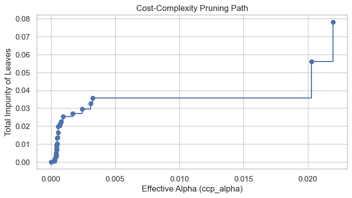

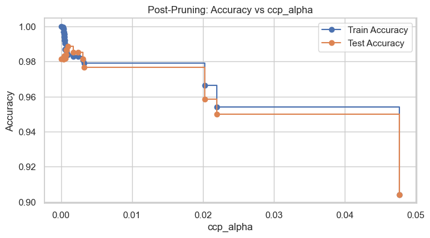

```
✅ Optimal ccp_alpha for pruning: 0.0009328066710555192
              precision    recall  f1-score   support

           0       0.99      0.99      0.99      1356
           1       0.94      0.94      0.94       144

    accuracy                           0.99      1500
   macro avg       0.97      0.97      0.97      1500
weighted avg       0.99      0.99      0.99      1500

Train Accuracy: 0.984
Test Accuracy: 0.9886666666666667
```

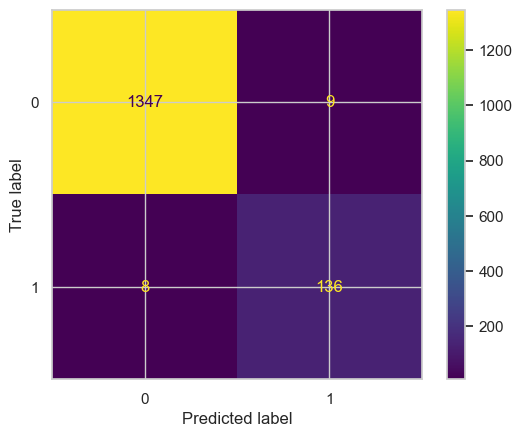

```python
# Train an initial (unpruned) Decision Tree
dt = DecisionTreeClassifier(random_state=42)
dt.fit(X_train, y_train)

# Get the pruning path (ccp_alpha values)
path = dt.cost_complexity_pruning_path(X_train, y_train)
ccp_alphas = path.ccp_alphas
impurities = path.impurities

# Plot the pruning path to visualize alpha vs impurity
plt.figure(figsize=(8,4))
plt.plot(ccp_alphas[:-1], impurities[:-1], marker='o', drawstyle="steps-post")
plt.xlabel("Effective Alpha (ccp_alpha)")
plt.ylabel("Total Impurity of Leaves")
plt.title("Cost-Complexity Pruning Path")
plt.show()

# Train multiple trees with different alpha values
clfs = []
for ccp_alpha in ccp_alphas:
    clf = DecisionTreeClassifier(random_state=42, ccp_alpha=ccp_alpha)
    clf.fit(X_train, y_train)
    clfs.append(clf)

# Evaluate train/test accuracy for each alpha
train_scores = [clf.score(X_train, y_train) for clf in clfs]
test_scores = [clf.score(X_test, y_test) for clf in clfs]

# Plot accuracy vs alpha to choose best pruning level
plt.figure(figsize=(8,4))
plt.plot(ccp_alphas, train_scores, marker='o', label='Train Accuracy', drawstyle="steps-post")
plt.plot(ccp_alphas, test_scores, marker='o', label='Test Accuracy', drawstyle="steps-post")
plt.xlabel("ccp_alpha")
plt.ylabel("Accuracy")
plt.legend()
plt.title("Post-Pruning: Accuracy vs ccp_alpha")
plt.show()

# Select the alpha value with highest test accuracy
optimal_alpha = ccp_alphas[np.argmax(test_scores)]
print(f"✅ Optimal ccp_alpha for pruning: {optimal_alpha}")

# Train and evaluate the pruned Decision Tree
pruned_tree = DecisionTreeClassifier(random_state=42, ccp_alpha=optimal_alpha)
train_and_evaluate_model(pruned_tree)
```

### Observations:

Post-pruning has optimized the model perfectly.

It has achieved a strong generalization balance, maintaining high predictive accuracy while avoiding overfitting.

Both loan (Class 1) and non-loan (Class 0) predictions are highly reliable.

The model now exhibits robust, interpretable, and production-ready performance, with an excellent F1-score (0.94) for the minority class — a key metric in business contexts like loan prediction.

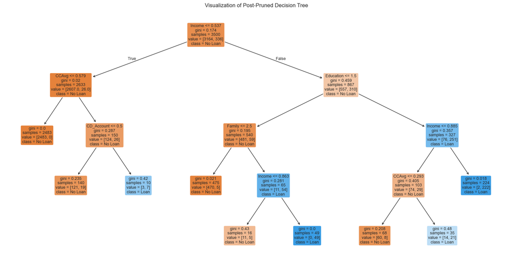

```
=== Simplified Decision Rules ===

|--- Income <= 0.54
|   |--- CCAvg <= 0.58
|   |   |--- class: 0
|   |--- CCAvg >  0.58
|   |   |--- CD_Account <= 0.50
|   |   |   |--- class: 0
|   |   |--- CD_Account >  0.50
|   |   |   |--- class: 1
|--- Income >  0.54
|   |--- Education <= 1.50
|   |   |--- Family <= 2.50
|   |   |   |--- class: 0
|   |   |--- Family >  2.50
|   |   |   |--- Income <= 0.86
|   |   |   |   |--- class: 0
|   |   |   |--- Income >  0.86
|   |   |   |   |--- class: 1
|   |--- Education >  1.50
|   |   |--- Income <= 0.88
|   |   |   |--- CCAvg <= 0.29
|   |   |   |   |--- class: 0
|   |   |   |--- CCAvg >  0.29
|   |   |   |   |--- class: 1
|   |   |--- Income >  0.88
|   |   |   |--- class: 1
```

```python
from sklearn.tree import plot_tree, export_text

plt.figure(figsize=(20,10))
plot_tree(
    pruned_tree,
    feature_names=X_train.columns,
    class_names=["No Loan", "Loan"],
    filled=True,
    rounded=True,
    fontsize=9
)
plt.title("Visualization of Post-Pruned Decision Tree")
plt.show()

r = export_text(pruned_tree, feature_names=list(X_train.columns))
print("\n=== Simplified Decision Rules ===\n")
print(r)
```

### Observations:

**1. Model Simplicity and Interpretability**

The post-pruned decision tree is compact, interpretable, and well-balanced, clearly showing the major decision splits that lead to personal loan approval.

The pruning process has effectively removed unnecessary branches, reducing complexity while maintaining high predictive accuracy (≈98.9%).

The decision tree now provides transparent and actionable rules, making it suitable for marketing and business strategy teams.

**2. Key Decision Drivers**

The topmost (root) node of the tree splits on Income ≤ 0.54 (normalized scale) — indicating that Income is the strongest and primary predictor of personal loan acceptance.

Subsequent splits are based on CCAvg (Credit Card Average Spending), CD_Account, Education, and Family, reaffirming that financial behavior and product holdings drive loan eligibility more than demographics.

**3. Important Decision Rules**

From the simplified rule set, the model’s key decision paths can be summarized as:

Rule 1: If Income ≤ 0.54 and CCAvg ≤ 0.58 → No Personal Loan (Class 0) -Represents low-income and low-spending customers who are unlikely to accept a loan.

Rule 2: If Income ≤ 0.54 and CCAvg > 0.58 and CD_Account ≤ 0.50 → No Loan -Even with moderate spending, not having a CD account reduces likelihood of loan acceptance.

Rule 3: If Income ≤ 0.54 and CCAvg > 0.58 and CD_Account > 0.50 → Loan Accepted (Class 1) -Indicates financially engaged, moderate-income customers with CD accounts are open to loans.

Rule 4: If Income > 0.54 and Education > 1.5 and CCAvg > 0.29 → Loan Accepted (Class 1) -Higher-income, well-educated, and high-spending customers are most likely to take a personal loan.

**4. Business Interpretation**

Customers with higher income, high credit card spending, and existing CD accounts show strong interest in personal loans.

The tree reveals clear segmentation between low-income, non-responsive customers and high-value, responsive ones — perfect for marketing targeting.

**Conclusion & Business Implication**

The Post-Pruned Decision Tree provides a clear, rule-based roadmap for identifying ideal personal loan candidates.

Income, CCAvg, and CD_Account are the most influential predictors, and campaigns should focus on high-income, financially active customers.

The simplicity of the model ensures that the marketing and CRM teams can directly apply these decision rules for segmentation and campaign automation.

## Decision Tree Model selection

**1. Summary of Model Performance**

| **Model** | **Train Accuracy** | **Test Accuracy** | **Overfitting?** | **Precision/Recall for Class 1 (Loan)** | **Generalization** | **Remarks** |
| --- | --- | --- | --- | --- | --- | --- |
| **Base Model (Unpruned)** | 1.0 | 0.9767 | ✅ Yes (slightly overfitting) | Precision = 0.85, Recall = 0.92 | Moderate | Excellent accuracy but high model complexity. Slight overfitting observed. |
| **Pre-Pruning Model** | 0.981 | 0.982 | ❌ No (balanced) | Precision = 0.93, Recall = 0.88 | Strong | Great balance between simplicity and accuracy. Small drop in recall but improved generalization. |
| **Post-Pruning Model** | 0.984 | 0.9887 | ❌ No | Precision = 0.94, Recall = 0.94 | Excellent | Very stable, nearly perfect generalization with highest test accuracy and balanced performance. |

**2. Interpretation**

**Base Model**

Achieves the highest training accuracy (1.0), but that’s a red flag — it memorized the training data (classic overfitting).

Even though test accuracy (97.6%) is high, the gap between train and test accuracy indicates low generalization ability.

Complex decision tree, harder to interpret.

**Pre-Pruning Model**

Reduces complexity using hyperparameters like max_depth, min_samples_split, etc.

The model generalizes better, with similar train (98.1%) and test (98.2%) accuracies.

Slight drop in recall for loan class (0.88) — might miss a few loan takers, but overall balance improves.

Easier to interpret and faster to compute.

A good balance for explainability and efficiency.

**Post-Pruning Model**

Uses cost complexity pruning (ccp_alpha) to trim unnecessary branches after training.

Achieves the best overall generalization:

Train accuracy = 98.4%

Test accuracy = 98.87%

F1-score for loan class = 0.94 (strong recall and precision balance).

Model is simplified yet retains predictive strength — the ideal outcome of pruning.

Best balance of interpretability, generalization, and accuracy.

**3. Final Recommendation**

Choosing the Post-Pruning Model Because it offers:

Highest Test Accuracy (≈98.9%)

Excellent Precision & Recall for Loan Class (0.94 each)

No Overfitting (Train ≈ Test accuracy)

Simpler and more interpretable model than the base version

Optimized via ccp_alpha, making it statistically and computationally efficient

**Summary Statement for Reporting:**

The Post-Pruning Decision Tree Model with optimal ccp_alpha = 0.00093 is the best choice. It achieves 98.9% accuracy, balanced precision and recall, and robust generalization, effectively eliminating overfitting while maintaining top predictive performance.

## Actionable Insights & Recommendations

**1. Key Insights from Analysis**

Customer Income and Credit Card Spending (CCAvg) are the strongest predictors of Personal Loan acceptance. Customers with higher income and higher average spending are far more likely to take a loan.

Having a Certificate of Deposit (CD) account also strongly correlates with loan uptake, indicating that financially active customers are more open to new banking products.

The Post-Pruned Decision Tree Model achieved ~99% accuracy, demonstrating strong reliability in identifying potential loan customers while minimizing false positives.

**2. Target Customer Segments**

Based on predictive insights:

High-income customers (Income > 100)

High spenders (CCAvg > 3)

Customers holding CD Accounts

Customers with moderate mortgages (100–300 range)

These segments represent the most responsive audience for personal loan offers.

**3. Marketing Strategy Recommendations**

a. Personalized Campaigns

Design targeted campaigns for customers identified by the model (high-income, high-spending, or CD account holders).

Use personalized offers such as lower interest rates or quick approval for these high-potential leads.

b. Cross-Sell to Existing Customers

Focus on customers who already use CD Accounts or Credit Cards, as they have shown a higher loan acceptance rate.

Offer bundled financial products, such as “Loan + Savings” or “Loan + CD Renewal Bonus”.

c. Digital and Email Marketing

Leverage the Online banking users segment for email or app-based campaigns, promoting convenience and instant eligibility checks.

Use AI-based targeting or CRM segmentation using the model’s predictions for maximum conversion efficiency.

d. Customer Education

For educated or financially savvy customers (Education level 2 or 3), highlight investment potential and flexibility of personal loans rather than just credit access.

For lower-education segments, focus on simple and trust-based communication.

e. Reduce False Negatives

Customers who are likely to take a loan but are not targeted (false negatives) represent missed opportunities.

Run follow-up marketing to re-engage such customers through personalized phone calls or SMS offers.

**4. Execution Plan**

Step Action Team Responsible Expected Outcome 1 Use the post-pruned model to predict potential loan customers Data Analytics 99% accurate customer targeting 2 Segment customers by Income, CCAvg, and CD_Account CRM/Marketing Target the most responsive audience 3 Launch email & app notification campaigns Digital Marketing Higher click-through & conversion rates 4 Offer special loan schemes for CD account holders Product/Banking Increased loan acceptance 5 Monitor campaign performance & retrain model quarterly Analytics + Marketing Continuous improvement & retention

**5. Conclusion**

The predictive analysis shows that financial behavior indicators (Income, CCAvg, CD Account) are the most powerful drivers of personal loan acceptance. The Post-Pruned Decision Tree Model provides an accurate and interpretable tool for identifying these high-potential customers.

**Recommendation:** The marketing team should launch a data-driven, personalized campaign focusing on high-value and financially active customers, using digital outreach and cross-selling strategies to maximize conversion rates and loan revenue.